# Estimating the causal effects of Krasner’s tenure as District Attorney on criminal charges and other outcomes

Vitaly Lorman

3/25/2021

## Introduction

Elected in November 2017, Philadelphia District Attorney Larry Krasner ran on a platform whose stated top priority was ending mass incarceration in Philadelphia (“Krasner for Da,” n.d.). A self-described progressive DA, Krasner’s campaign promised, among other things, to stop prosecuting “insufficient and insignificant cases”, to treat addiction as a public safety issue, and to work to stop pursuing extreme sentences Austen (2018). Running for re-election in 2021, Krasner’s campaign proclaims a 40% decrease in the county jail population, reductions in sentence length, an end to charging marijuana possession cases, diversion of other drug possession cases to treatment, and a shifting of resources to solving serious crimes, particularly homicides and gun violence. (“Krasner for Da: Promises Kept,” n.d.)

Both prior to and over the course of Krasner’s tenure, the crime rate across various offenses, measured both by incidents reported by Philadelphia and nearby county police agencies to the FBI’s Uniform Crime Reporting (UCR) Program and by police arrests reported by the DA’s office, has varied substantially. Since the DA’s office only enters the criminal justice process after an arrest has been made, we include arrest counts by date across a variety of offense categories among the covariates that we control over. We argue that the most substantial potential confounders effect the charge counts only through their effect on the number of arrests across various categories and that consequently, by controlling for arrests, we produce estimates of the causal effect of Krasner’s tenure as DA on the number of charges brough for various offense types.

## Background on the criminal justice process in Philadelphia

The District Attorney’s Office typically only gets involved in a case once an arrest has been made (by Philedelphia Police Department or other agency such that jurisdiction for prosecuting the case falls under Philadelphia County). At the first stage of this process, the DA’s office decides whether to bring charges and what charges to bring. Subsequently, bail is set by a Bail Magistrate, taking into account input from both the DA’s office and the attorney for the defense. In some cases, instead of bringing charges, the DA’s office can decide to divert a case into one of various diversionary programs. If charges are brought, a case proceeds through the judicial system to an outcome (verdict, guilty plea, dismissal, or withdrawal). One of the DA’s many roles in this part of the process is making plea offers. After an outcome, the case proceeds to sentencing. The judge imposes a sentence with recommendations from the DAO. A single case may have many charges, and distinct charges may have different outcomes. Different outcomes subject to sentencing may receive different sentences, and these sentences may be imposed concurrently with others or consecutively.

In this document, we are presently interested in the part of the process that involves charges. Charges for offenses correpond to statutes in the Pennsylvania Criminal Law. The publicly availably data from the DAO that we will be using in our analysis counts only the most serious charge (subject to the most severe sentence) for each case. To help our analysis and interpretability, we group the possible charges into six groups based on the DAO’s grouping of these charges on their website (“Philadelphia Dao Data Dashboard,” n.d.). These groups, and the kinds of charges that comprise them, are as follows:

- **Violent charges:** Homicide, Non-fatal shooting, Rape", Robbery with a gun, Robbery (other), Aggravated assault with a gun, Aggravated assault (other), Other assaults, Sexual assaults and other sex offenses
- **Property charges:** Residential burglary, Commercial burglary, Theft of motor vehicle tag, Theft from person, Theft from auto, Retail theft", Theft, Auto theft, Fraud Theft of Services, Embezzlement
- **Drug charges:** Drug possession, Drug sales, DUI
- **Firearms charges:** Illegal firearms possession
- **Other charges:** Prostitution or sex work, Patronizing prostitutes, Threats of violence
- **Uncategorized charges:** All other charges brough by the DAO that do not fall into the categories above.

## The data

### Source of data

The data we use in our observational study is publicly available and was downloaded on March 22, 2021 from the District Attorney’s Office GitHub repository (“Philadelphia Dao Github Repository,” n.d.). Specifically, we use the data frames consisting of counts of charges and of arrests by date, grouped by categories of offenses which are similar, but not identical to the FBI UCR Program categories of Type I and Type II crime.

We read in the resulting datasets and summarise.

```r
charges_all<-read.csv("charges_all.csv", row.names=1)
charges_all_long<-read.csv("charges_all_long.csv", row.names=1)
charges_all$date_value<-as.Date(charges_all$date_value)
charges_all_long$date_value<-as.Date(charges_all_long$date_value)

summary(charges_all)
```

```
##    date_value         arrests_violent arrests_property arrests_drugs
##  Min.   :2014-01-01   Min.   : 5.00   Min.   : 1.00    Min.   :  2.00
##  1st Qu.:2015-06-04   1st Qu.:20.00   1st Qu.:11.00    1st Qu.: 28.00
##  Median :2016-11-05   Median :24.00   Median :15.00    Median : 39.00
##  Mean   :2017-01-15   Mean   :25.39   Mean   :15.98    Mean   : 40.73
##  3rd Qu.:2018-10-11   3rd Qu.:30.00   3rd Qu.:20.00    3rd Qu.: 52.00
##  Max.   :2020-03-14   Max.   :88.00   Max.   :96.00    Max.   :125.00
##  arrests_firearms arrests_other    arrests_uncategorized charges_violent
##  Min.   : 0.000   Min.   : 0.000   Min.   : 3.00         Min.   : 6.00
##  1st Qu.: 2.000   1st Qu.: 1.000   1st Qu.:20.00         1st Qu.:20.00
##  Median : 3.000   Median : 3.000   Median :25.00         Median :25.00
##  Mean   : 3.478   Mean   : 3.565   Mean   :25.01         Mean   :26.24
##  3rd Qu.: 5.000   3rd Qu.: 5.000   3rd Qu.:30.00         3rd Qu.:31.50
##  Max.   :22.000   Max.   :24.000   Max.   :51.00         Max.   :94.00
##  charges_property charges_drugs    charges_firearms charges_other
##  Min.   :  1.00   Min.   :  2.00   Min.   : 0.000   Min.   : 0.000
##  1st Qu.: 11.00   1st Qu.: 26.00   1st Qu.: 2.000   1st Qu.: 1.000
##  Median : 15.00   Median : 38.00   Median : 3.000   Median : 2.000
##  Mean   : 16.46   Mean   : 39.59   Mean   : 3.408   Mean   : 3.195
##  3rd Qu.: 20.00   3rd Qu.: 52.00   3rd Qu.: 5.000   3rd Qu.: 5.000
##  Max.   :147.00   Max.   :114.00   Max.   :17.000   Max.   :38.000
##  charges_uncategorized treatment
##  Min.   : 1.00         Mode :logical
##  1st Qu.: 8.00         FALSE:1275
##  Median :11.00         TRUE :804
##  Mean   :11.84
##  3rd Qu.:15.00
##  Max.   :52.00
```

## Observational study design

We set up our observational study such that a single unit consists of a day on which criminal charges in the Philadelphia Municipal Court or Common Pleas court could be brought within a specified range of dates.

### Treatment

Given a unit in our study–a day with with a collection of criminal cases that receive potential charges–we define the treatment to be having the cases that day charged by the DA’s office under Krasner. The control is having the cases that day charged by the office of Krasner’s predecessor, former DA Seth Williams.

Note that our treatment is defined somewhat narrowly, and in particular, the treatment does not include other actions or conditions during Krasner’s tenure as head of the DAO, even those initiated by the DAO. Our treatment is strictly defined whether Krasner’s office charges the cases on a given day. See the Assumptions section for further discussion of this.

Also note that we are not studying the causal effect of Krasner himself but the effect of the entire DAO under Krasner’s leadership (as opposed to the control of the DAO under Williams’ leadership). We view the treatment as binary (see the Discussion section for more on this).

### Outcomes

As discussed above, we group offenses into six groups (violent, property, drugs, firearms, other, and uncategorized). Our outcomes of interest are, for each offense type, the number of cases in which a charge of that type was brought as the most serious charge in that case. We measure outcomes as a difference in means between treatment and control group as well as a percent change relative to the control group mean.

## Covariates

The number of charges on a given day, by category, is caused by a number of factors: the number of criminal incidents in previous weeks, the number of arrests, policing practices such as gathering of evidence and writing reports, criminal law (local, state, and federal), criminal records of defendants, police department policies, and DA office policy and practice regarding charges. The DAO is the final actor in a complicated process.

For most of the covariates that come prior to the DAO’s role in the process, their effect on our outcomes of interest (mean daily charges by offense category) is indirect and goes through the number of arrests. For instance, policy department policies regarding whether to make arrests for a given type of offense and how actively to pursue enforcing it will only effect charges through the number of arrests made for that type of offense. Thus, our covariates consist of daily arrest totals by offense category. By conditioning on these, we remove confounding by many of the factors mentioned above.

### Assumptions

We assume stable unit treatment values (SUTVA); that is, we assume that the outcomes of one unit (that is, the count of most serious charges in cases from one day by type) do not vary with the treatments assigned to other units. In other words, given a day, the charge counts from that day do not vary depending on whether the cases from a different day were by Krasner’s office or Williams’. This assumption could be violated in the case of reoffenders if the past criminal record of a defendant had an effect on the sorts of charges that were brought in their case. We assume that the effect of such instances is negligible, though a data set that contained information on reoffenders would lead to a more refined analysis.

As defined above, we also assume that there is only one form of the treatment. This assumption would be violated if during Krasner’s tenure as DA, the DAO changed its policies or practices in charging certain kinds of cases. This would be particularly of concern in the first few months of Krasner’s tenure as DA when big changes occured in the DAO (for instance, 31 staffers, including prosecutors, left the DAO in the first week of Krasner’s tenure). We address this assumption further and conduct a sensitivity analysis in the Discussion section of this document.

We assume that unobserved covariates have negligible impact on our estimates. Unobserved covariates that are of potential concern are ones that have a direct effect on charge counts rather than an indirect one through arrest counts. These could include quality of policy reports and evidence-gathering, prior criminal records of defendants, defendant demographics, and local, state, or federal policies regarding charges for certain types of offenses. The data available to us does not contain many of these. We address how robust our analysis is to their impact through sensitivity analyses in the Discussion section below.

Finally, we assume there is no post-treatment bias; that is, the distribution of arrest counts does not vary with treatment assignment. At first glance, days charged during Krasner’s tenure as DA have a different distribution of arrests from days charged prior to Krasner’s tenure as DA. However, we recall that our definition of treatment is quite narrow: we say that a unit (day) in our study has received the treatment if the cases on that day were charged by Krasner’s office, and a unit has received the control if the cases were charged by Williams’ office. In particular, our definition of treatment does not include any actions by the DAO or anyone else that effect arrests: for each individual unit, arrest counts are pre-treatment covariates and are uneffected by the treatment assignment. While the DAO could very well have a causal effect on arrest counts by, for instance, instituting a policy of not charging certain kinds of offenses causing the police not to make arrests for those offenses, this kind of action of the DAO does not fall within our definition of treatment, and so is not measured by our causal estimates. We are simply measuring the effect of Krasner’s DAO on charging the arrests they are given. Any other effects of the DAO on charges are outside the scope of our study.

### Outline of analysis

Our method of analysis will be to use a linear regression to estimate the treatment effect on charge counts by type regressing on covariates giving arrest counts by type. In order to ensure that the arrest count covariates are similarly distributed between the treatment and control groups, we implement nearest-neighbor matching with calipers (further discussed below). Upon achieving our desired balance, we fit a linear model to the matched data to estimate the desired causal effects.

## Summary of trends in the data

Before we conduct our analysis, we begin by presenting some summaries of our data. First, we show the counts for charges and arrests by type. For this chart, we use a version of the charges_all_long data frame in which the dates between 2017-06-29 and 2018-01-01 and the dates after 2020-03-25 have not been excluded.

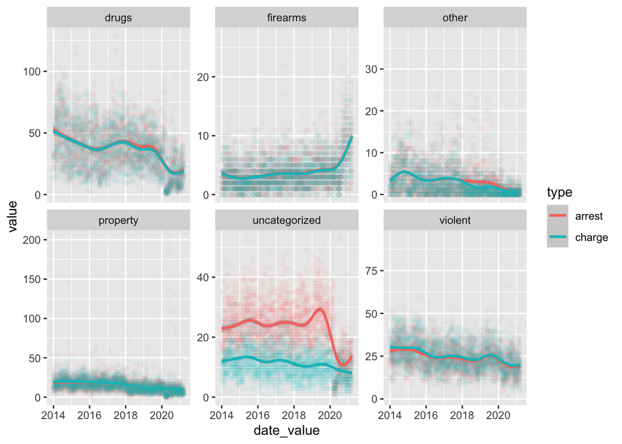

```r
all_dates_long<-read.csv("charges_all_long_full.csv", row.names=1)
all_dates_long$date_value<-as.Date(all_dates_long$date_value)

ggplot(data=all_dates_long, aes(x=date_value, y=value, col=type))+
  geom_point(alpha=0.03)+
  geom_smooth()+
  facet_wrap(~group, scale="free_y")
```

Next, we restrict our focus to the time periods of our control group (2014-01-01 to 2017-06-29) and our treatment group (2018-01-01 to 2020-03-15) and show the control and treatment means for arrests and charges by type, along with the percent in change from the control mean.

```r
charges_all_long$treatment<-charges_all_long$date_value>="2018-01-01"
means<-charges_all_long %>%
  group_by(treatment, type, group) %>%
  summarise(mean=mean(value)) %>%
  dcast(group+type~treatment, value.var="mean")

colnames(means)[3:4]<-c("control", "treatment")
means$diff_in_means<-means$treatment-means$control
means$percent_diff_in_means<-100*means$diff_in_means/means$control
##differences in means of charges
charge_diffs<-means %>%
  filter(type=="charge") %>%
  select("group", "diff_in_means", "percent_diff_in_means")

charge_diffs
```

```
##           group diff_in_means percent_diff_in_means
## 1         drugs     -5.203693             -12.50911
## 2      firearms      0.746456              23.93089
## 3         other     -2.259318             -55.52488
## 4      property     -6.717053             -35.25250
## 5 uncategorized     -1.782953             -14.23460
## 6       violent     -3.501361             -12.68970
```

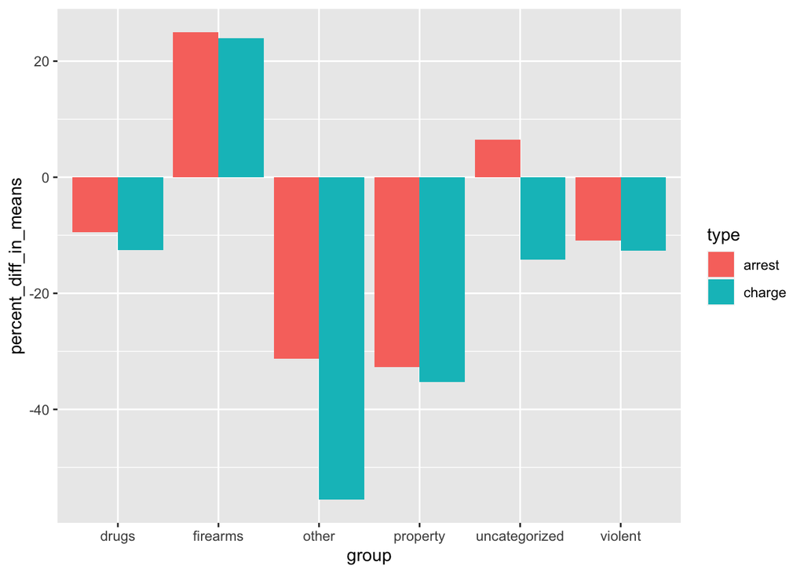

```r
ggplot(data=means, aes(x=group, y=percent_diff_in_means, fill=type))+
  geom_bar(position="dodge", stat="identity")
```

## Matching

Our causal effect estimates will come from fitting a linear model, controlling for arrest count covariates for each of our six types of offenses. Before fitting the model, in this section we employ matching to account for imbalance of covariates in our treatment and control groups, following Daniel E. Ho and Stuart (2007). First, here is a plot of the distributions of mean arrest counts by type, along with a QQ plot for each plot:

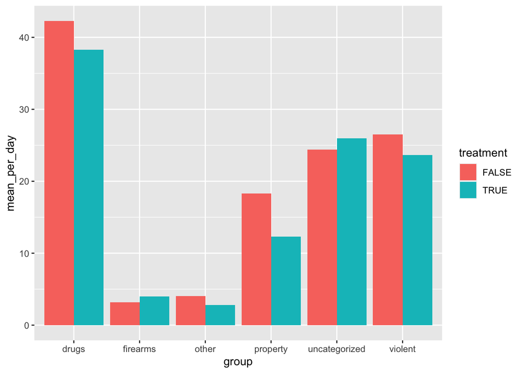

```r
arrest_count_sum<-charges_all_long %>%
  filter(type=="arrest") %>%
  group_by(group, treatment) %>%
  summarise(mean_per_day=mean(value))

ggplot(data=arrest_count_sum, aes(x=group, y=mean_per_day, fill=treatment))+
  geom_bar(position="dodge", stat="identity")
```

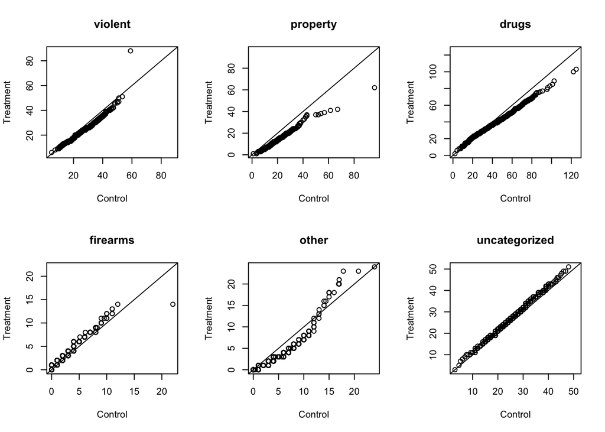

```r
##Construct data with empirical quantiles for control and treatment groups

par(mfrow=c(2,3))
for (g in unique(charges_all_long$group))
{
  x<-filter(charges_all_long, type=="arrest", group==g, !treatment)$value
  y<-filter(charges_all_long, type=="arrest", group==g, treatment)$value
  qqplot(x, y, main=g,
  xlab="Control",
  ylab="Treatment",
  xlim=c(min(x, y), max(x, y)),
  ylim=c(min(x, y), max(x, y)))
  abline(0,1)
}
```

```r
#mtext("QQ plots for mean daily arrest counts by offense group", outer=TRUE,side=3,line=0, cex=1.5)
```

We see imbalance for some of the arrest types, particularly property, drugs, and other.

To address this imbalance, we implementing matching on propensity scores. Following Daniel E. Ho and Stuart (2007) and appealing to the “propensity score tautology”, our sole concern is achieving balance on the covariates, and so whatever matching method we implement that yields our desired level of balance will do the job. We experimented with a variety of matching methods (further detailed in the “Matching.Rmd” document), and we found there to be somewhat of a tradeoff between sample sizes of matched data and balance. For example, using subclassification matching with 6 classes, we were able to get good balance, but at the expense of one of the subclasses having as few as 19 control units.

Here we print the summary of our matching method and a few plots that demonstrate balance.

```r
mcal1.out<-matchit(treatment~arrests_violent+arrests_property+arrests_drugs+arrests_other+arrests_firearms+arrests_uncategorized, data=charges_all, method="nearest", caliper=0.1, ratio=1275/804, min.controls=1, max.controls=3)
scal1.out <- summary(mcal1.out, standardize = TRUE)
scal1.out
```

```
##
## Call:
## matchit(formula = treatment ~ arrests_violent + arrests_property +
##     arrests_drugs + arrests_other + arrests_firearms + arrests_uncategorized,
##     data = charges_all, method = "nearest", caliper = 0.1, ratio = 1275/804,
##     min.controls = 1, max.controls = 3)
##
## Summary of Balance for All Data:
##                       Means Treated Means Control Std. Mean Diff. Var. Ratio
## distance                     0.5432        0.2880          1.1614     1.2204
## arrests_violent             23.6231       26.5059         -0.3895     0.8310
## arrests_property            12.3122       18.3004         -0.9657     0.6218
## arrests_drugs               38.2624       42.2847         -0.2705     0.6301
## arrests_other                2.7873        4.0549         -0.3664     0.8886
## arrests_firearms             3.9639        3.1710          0.3289     1.1302
## arrests_uncategorized       25.9801       24.3937          0.2096     1.1008
##                       eCDF Mean eCDF Max
## distance                 0.3013   0.4819
## arrests_violent          0.0585   0.1692
## arrests_property         0.1113   0.3838
## arrests_drugs            0.0445   0.1427
## arrests_other            0.0573   0.1924
## arrests_firearms         0.0500   0.1591
## arrests_uncategorized    0.0330   0.0988
##
##
## Summary of Balance for Matched Data:
##                       Means Treated Means Control Std. Mean Diff. Var. Ratio
## distance                     0.4517        0.4390          0.0578     1.0869
## arrests_violent             24.5154       24.4619          0.0072     1.0359
## arrests_property            13.9673       14.3285         -0.0582     1.2431
## arrests_drugs               39.5608       39.2465          0.0211     0.7711
## arrests_other                3.1924        3.1951         -0.0008     1.4480
## arrests_firearms             3.5590        3.6010         -0.0174     0.7509
## arrests_uncategorized       25.2686       25.0091          0.0343     0.9290
##                       eCDF Mean eCDF Max Std. Pair Dist.
## distance                 0.0136   0.0563          0.0416
## arrests_violent          0.0096   0.0387          1.0887
## arrests_property         0.0117   0.0538          0.6803
## arrests_drugs            0.0210   0.0696          1.2609
## arrests_other            0.0173   0.0466          1.0641
## arrests_firearms         0.0134   0.0517          0.9621
## arrests_uncategorized    0.0084   0.0321          1.0662
##
## Percent Balance Improvement:
##                       Std. Mean Diff. Var. Ratio eCDF Mean eCDF Max
## distance                         95.0       58.2      95.5     88.3
## arrests_violent                  98.1       81.0      83.6     77.1
## arrests_property                 94.0       54.2      89.4     86.0
## arrests_drugs                    92.2       43.7      52.9     51.3
## arrests_other                    99.8     -213.5      69.8     75.8
## arrests_firearms                 94.7     -134.0      73.2     67.5
## arrests_uncategorized            83.6       23.4      74.7     67.5
##
## Sample Sizes:
##               Control Treated
## All           1275.       804
## Matched (ESS)  733.04     551
## Matched        920.       551
## Unmatched      355.       253
## Discarded        0.         0
```

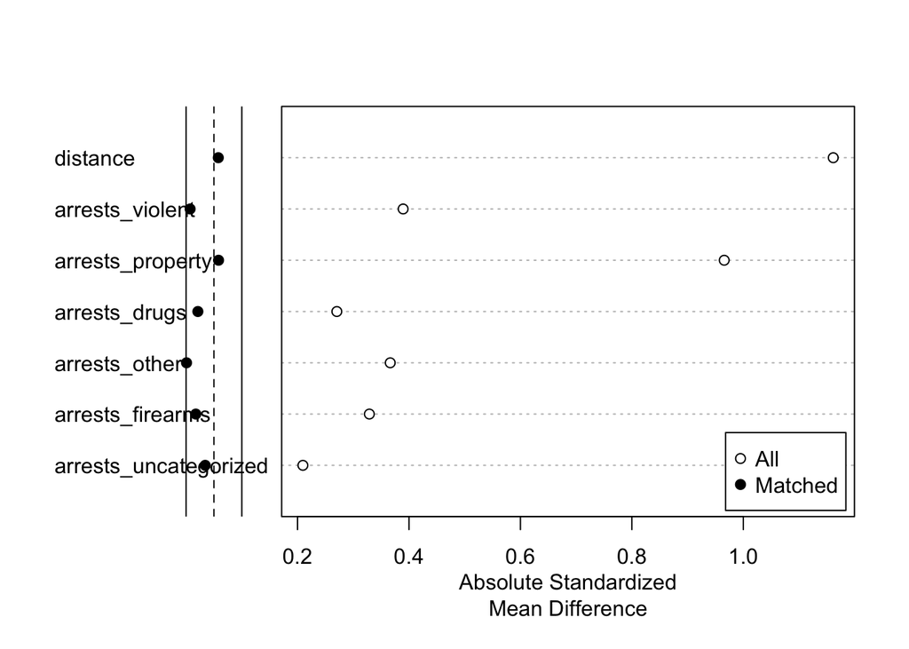

```r
plot(scal1.out)
```

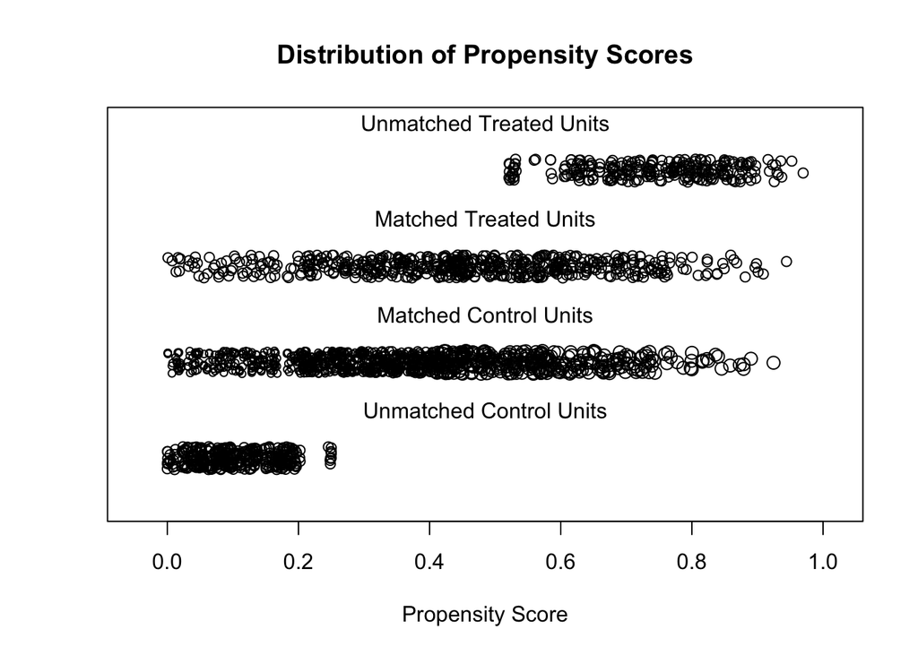

```r
plot(mcal1.out,  type = "jitter", interactive = FALSE)
```

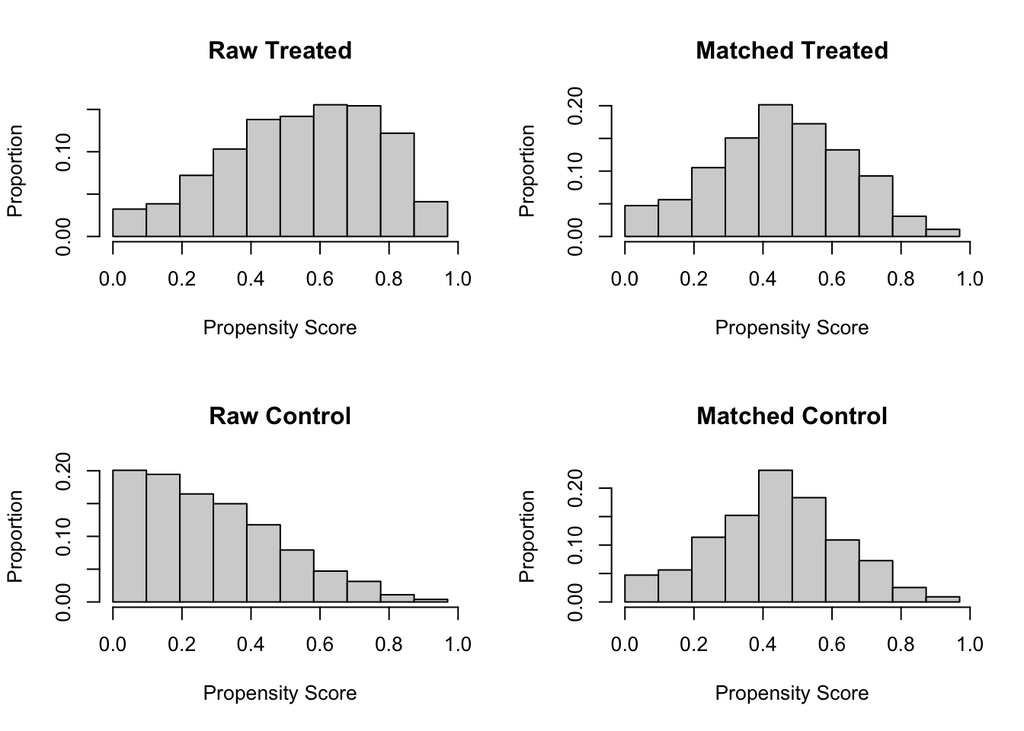

```r
plot(mcal1.out,  type = "hist")
```

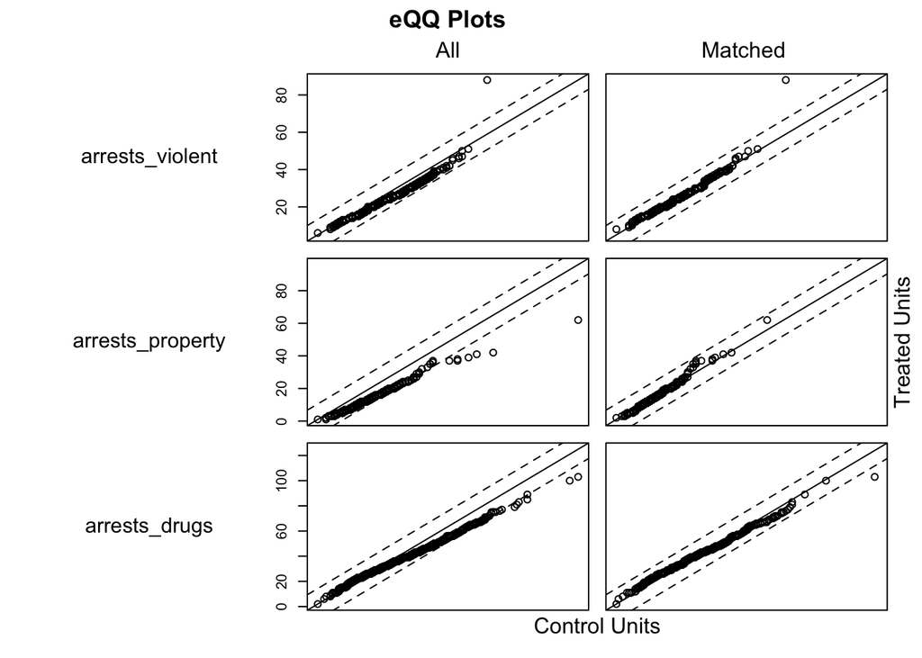

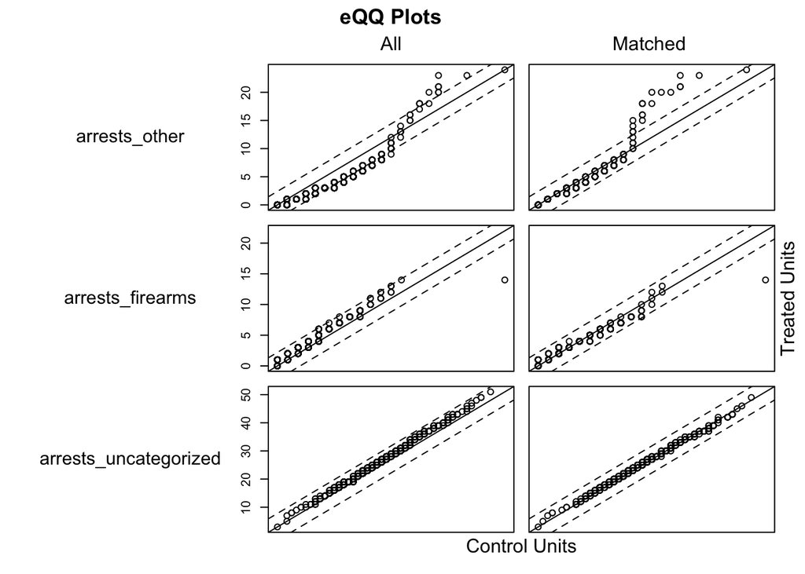

```r
plot(mcal1.out, type="qq")
```

```r
matched_data2<-match.data(mcal1.out)
matched_data2$treatment<-as.numeric(matched_data2$treatment)
```

## Fitting a linear model

Now that we have achieved balance between treatment and control groups, we fit a linear model to the data. For each outcome of interest (charge counts for each of the 6 offense groups), we regress on the binary treatment variable and the arrest counts for each of the 6 offense groups.

We print the summary of each linear model below.

```r
lm_violent<-lm(charges_violent~treatment+arrests_violent+arrests_property+arrests_drugs+arrests_firearms+arrests_other+arrests_uncategorized, data=matched_data2)
#x.out <- setx(z.out, data = match.data(m.out), fn = NULL, cond = TRUE)
#s.out <- sim(z.out, x = x.out)
summary(lm_violent)
```

```
##
## Call:
## lm(formula = charges_violent ~ treatment + arrests_violent +
##     arrests_property + arrests_drugs + arrests_firearms + arrests_other +
##     arrests_uncategorized, data = matched_data2)
##
## Residuals:
##     Min      1Q  Median      3Q     Max
## -39.165  -4.617  -0.549   4.075  67.559
##
## Coefficients:
##                       Estimate Std. Error t value Pr(>|t|)
## (Intercept)            9.59362    0.85559  11.213  < 2e-16 ***
## treatment             -1.63853    0.38494  -4.257 2.21e-05 ***
## arrests_violent        0.53249    0.02490  21.384  < 2e-16 ***
## arrests_property       0.04125    0.03019   1.366  0.17204
## arrests_drugs          0.02994    0.01287   2.326  0.02013 *
## arrests_firearms      -0.09221    0.08413  -1.096  0.27326
## arrests_other          0.16001    0.05885   2.719  0.00663 **
## arrests_uncategorized  0.06408    0.02862   2.239  0.02531 *
## ---
## Signif. codes:  0 '***' 0.001 '**' 0.01 '*' 0.05 '.' 0.1 ' ' 1
##
## Residual standard error: 6.996 on 1463 degrees of freedom
## Multiple R-squared:  0.3186, Adjusted R-squared:  0.3153
## F-statistic: 97.72 on 7 and 1463 DF,  p-value: < 2.2e-16
```

```r
lm_property<-lm(charges_property~treatment+arrests_violent+arrests_property+arrests_drugs+arrests_firearms+arrests_other+arrests_uncategorized, data=matched_data2)
#x.out <- setx(z.out, data = match.data(m.out), fn = NULL, cond = TRUE)
#s.out <- sim(z.out, x = x.out)
summary(lm_property)
```

```
##
## Call:
## lm(formula = charges_property ~ treatment + arrests_violent +
##     arrests_property + arrests_drugs + arrests_firearms + arrests_other +
##     arrests_uncategorized, data = matched_data2)
##
## Residuals:
##     Min      1Q  Median      3Q     Max
## -24.592  -3.595  -0.865   2.495 128.375
##
## Coefficients:
##                        Estimate Std. Error t value Pr(>|t|)
## (Intercept)            7.404964   0.873176   8.480  < 2e-16 ***
## treatment             -2.964401   0.392853  -7.546 7.86e-14 ***
## arrests_violent        0.028109   0.025413   1.106 0.268875
## arrests_property       0.511002   0.030813  16.584  < 2e-16 ***
## arrests_drugs          0.008959   0.013132   0.682 0.495209
## arrests_firearms       0.084886   0.085863   0.989 0.323009
## arrests_other          0.206995   0.060064   3.446 0.000585 ***
## arrests_uncategorized  0.007616   0.029211   0.261 0.794347
## ---
## Signif. codes:  0 '***' 0.001 '**' 0.01 '*' 0.05 '.' 0.1 ' ' 1
##
## Residual standard error: 7.14 on 1463 degrees of freedom
## Multiple R-squared:  0.2496, Adjusted R-squared:  0.246
## F-statistic: 69.51 on 7 and 1463 DF,  p-value: < 2.2e-16
```

```r
lm_drugs<-lm(charges_drugs~treatment+arrests_violent+arrests_property+arrests_drugs+arrests_firearms+arrests_other+arrests_uncategorized, data=matched_data2)
#x.out <- setx(z.out, data = match.data(m.out), fn = NULL, cond = TRUE)
#s.out <- sim(z.out, x = x.out)
summary(lm_drugs)
```

```
##
## Call:
## lm(formula = charges_drugs ~ treatment + arrests_violent + arrests_property +
##     arrests_drugs + arrests_firearms + arrests_other + arrests_uncategorized,
##     data = matched_data2)
##
## Residuals:
##     Min      1Q  Median      3Q     Max
## -52.187  -6.793  -0.513   6.180  81.278
##
## Coefficients:
##                       Estimate Std. Error t value Pr(>|t|)
## (Intercept)           10.60379    1.30873   8.102 1.13e-15 ***
## treatment             -3.47140    0.58882  -5.896 4.63e-09 ***
## arrests_violent       -0.10307    0.03809  -2.706  0.00689 **
## arrests_property      -0.13375    0.04618  -2.896  0.00383 **
## arrests_drugs          0.81671    0.01968  41.494  < 2e-16 ***
## arrests_firearms       0.07805    0.12869   0.607  0.54427
## arrests_other         -0.07792    0.09002  -0.866  0.38690
## arrests_uncategorized  0.07685    0.04378   1.755  0.07941 .
## ---
## Signif. codes:  0 '***' 0.001 '**' 0.01 '*' 0.05 '.' 0.1 ' ' 1
##
## Residual standard error: 10.7 on 1463 degrees of freedom
## Multiple R-squared:  0.6365, Adjusted R-squared:  0.6348
## F-statistic:   366 on 7 and 1463 DF,  p-value: < 2.2e-16
```

```r
lm_firearms<-lm(charges_firearms~treatment+arrests_violent+arrests_property+arrests_drugs+arrests_firearms+arrests_other+arrests_uncategorized, data=matched_data2)
#x.out <- setx(z.out, data = match.data(m.out), fn = NULL, cond = TRUE)
#s.out <- sim(z.out, x = x.out)
summary(lm_firearms)
```

```
##
## Call:
## lm(formula = charges_firearms ~ treatment + arrests_violent +
##     arrests_property + arrests_drugs + arrests_firearms + arrests_other +
##     arrests_uncategorized, data = matched_data2)
##
## Residuals:
##     Min      1Q  Median      3Q     Max
## -9.7864 -1.0336 -0.1855  0.8962 14.3359
##
## Coefficients:
##                         Estimate Std. Error t value Pr(>|t|)
## (Intercept)            0.5660635  0.1998225   2.833  0.00468 **
## treatment              0.2494747  0.0899027   2.775  0.00559 **
## arrests_violent       -0.0007096  0.0058156  -0.122  0.90290
## arrests_property      -0.0080548  0.0070515  -1.142  0.25352
## arrests_drugs          0.0164700  0.0030052   5.480 4.99e-08 ***
## arrests_firearms       0.6403571  0.0196494  32.589  < 2e-16 ***
## arrests_other         -0.0121206  0.0137454  -0.882  0.37803
## arrests_uncategorized -0.0001594  0.0066847  -0.024  0.98098
## ---
## Signif. codes:  0 '***' 0.001 '**' 0.01 '*' 0.05 '.' 0.1 ' ' 1
##
## Residual standard error: 1.634 on 1463 degrees of freedom
## Multiple R-squared:  0.4761, Adjusted R-squared:  0.4735
## F-statistic: 189.9 on 7 and 1463 DF,  p-value: < 2.2e-16
```

```r
lm_other<-lm(charges_other~treatment+arrests_violent+arrests_property+arrests_drugs+arrests_firearms+arrests_other+arrests_uncategorized, data=matched_data2)
#x.out <- setx(z.out, data = match.data(m.out), fn = NULL, cond = TRUE)
#s.out <- sim(z.out, x = x.out)
summary(lm_other)
```

```
##
## Call:
## lm(formula = charges_other ~ treatment + arrests_violent + arrests_property +
##     arrests_drugs + arrests_firearms + arrests_other + arrests_uncategorized,
##     data = matched_data2)
##
## Residuals:
##      Min       1Q   Median       3Q      Max
## -11.9232  -1.0897  -0.0776   0.8453  11.2408
##
## Coefficients:
##                         Estimate Std. Error t value Pr(>|t|)
## (Intercept)            8.144e-01  2.401e-01   3.392 0.000713 ***
## treatment             -1.417e+00  1.080e-01 -13.118  < 2e-16 ***
## arrests_violent        5.569e-03  6.989e-03   0.797 0.425638
## arrests_property       4.930e-05  8.474e-03   0.006 0.995359
## arrests_drugs          8.846e-03  3.611e-03   2.450 0.014420 *
## arrests_firearms       6.420e-03  2.361e-02   0.272 0.785748
## arrests_other          6.488e-01  1.652e-02  39.279  < 2e-16 ***
## arrests_uncategorized -8.317e-05  8.033e-03  -0.010 0.991741
## ---
## Signif. codes:  0 '***' 0.001 '**' 0.01 '*' 0.05 '.' 0.1 ' ' 1
##
## Residual standard error: 1.964 on 1463 degrees of freedom
## Multiple R-squared:  0.6216, Adjusted R-squared:  0.6198
## F-statistic: 343.3 on 7 and 1463 DF,  p-value: < 2.2e-16
```

```r
lm_uncategorized<-lm(charges_uncategorized~treatment+arrests_violent+arrests_property+arrests_drugs+arrests_firearms+arrests_other+arrests_uncategorized, data=matched_data2)
#x.out <- setx(z.out, data = match.data(m.out), fn = NULL, cond = TRUE)
#s.out <- sim(z.out, x = x.out)
summary(lm_uncategorized)
```

```
##
## Call:
## lm(formula = charges_uncategorized ~ treatment + arrests_violent +
##     arrests_property + arrests_drugs + arrests_firearms + arrests_other +
##     arrests_uncategorized, data = matched_data2)
##
## Residuals:
##      Min       1Q   Median       3Q      Max
## -12.3517  -2.7661  -0.1735   2.4598  25.2811
##
## Coefficients:
##                        Estimate Std. Error t value Pr(>|t|)
## (Intercept)            3.918599   0.522517   7.499 1.11e-13 ***
## treatment             -2.317618   0.235087  -9.859  < 2e-16 ***
## arrests_violent        0.009724   0.015207   0.639   0.5226
## arrests_property      -0.033801   0.018439  -1.833   0.0670 .
## arrests_drugs          0.015449   0.007858   1.966   0.0495 *
## arrests_firearms       0.106041   0.051381   2.064   0.0392 *
## arrests_other         -0.020480   0.035943  -0.570   0.5689
## arrests_uncategorized  0.322270   0.017480  18.437  < 2e-16 ***
## ---
## Signif. codes:  0 '***' 0.001 '**' 0.01 '*' 0.05 '.' 0.1 ' ' 1
##
## Residual standard error: 4.273 on 1463 degrees of freedom
## Multiple R-squared:  0.2874, Adjusted R-squared:  0.284
## F-statistic: 84.28 on 7 and 1463 DF,  p-value: < 2.2e-16
```

## Results: summary of estimated causal effects

In the table below, we summarise our estimated causal effect for each offense group. We report the mean effect as well as the 95% confidence interval in both absolute counts and as percent change relative to the control mean.

```r
charge_type<-c("violent", "property", "drugs", "firearms", "other", "uncategorized")
effect_sum<-as.data.frame(charge_type)
effect_sum[,"treatment_effect"]<-
  rbind(lm_violent$coefficients["treatment"],
    lm_property$coefficients["treatment"],
    lm_drugs$coefficients["treatment"],
    lm_firearms$coefficients["treatment"],
    lm_other$coefficients["treatment"],
    lm_uncategorized$coefficients["treatment"])

effect_sum<-cbind(effect_sum,
  rbind(confint(lm_violent)["treatment",],
    confint(lm_property)["treatment",],
    confint(lm_drugs)["treatment",],
    confint(lm_firearms)["treatment",],
    confint(lm_other)["treatment",],
    confint(lm_uncategorized)["treatment",]))

colnames(effect_sum)[3:4]<-c("confmin", "confmax")

effect_sum<-cbind(effect_sum,
                  100*effect_sum[,c("treatment_effect","confmin", "confmax")]/
                    filter(means, type=="charge")[c(6, 4, 1, 2, 3, 5),"control"])

colnames(effect_sum)[5:7]<-c("percent_treatment_effect", "percent_confmin", "percent_confmax")
effect_sum
```

```
##     charge_type  treatment     confmin    confmax percent_treatment_effect
## 1       violent -1.6385268 -2.39362098 -0.8834327                -5.938379
## 2      property -2.9644006 -3.73501604 -2.1937852               -15.557795
## 3         drugs -3.4713957 -4.62640890 -2.3163826                -8.344859
## 4      firearms  0.2494747  0.07312272  0.4258266                 7.997993
## 5         other -1.4172731 -1.62920024 -1.2053459               -34.830825
## 6 uncategorized -2.3176179 -2.77876126 -1.8564745               -18.503211
##   percent_confmin percent_confmax
## 1       -8.675005       -3.201753
## 2      -19.602146      -11.513444
## 3      -11.121385       -5.568332
## 4        2.344266       13.651720
## 5      -40.039135      -29.622515
## 6      -22.184850      -14.821572
```

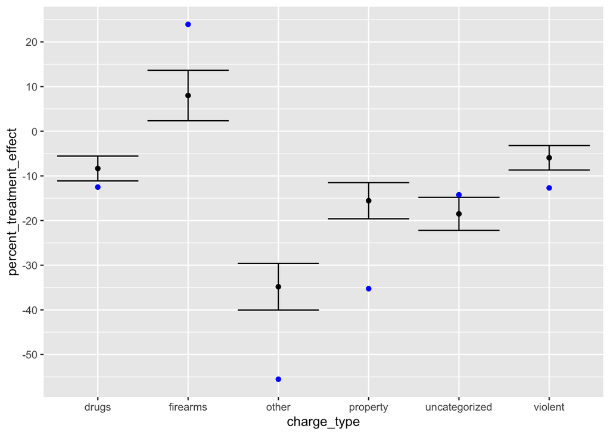

```r
#charge_diffs

effect_plot<-ggplot()+
  geom_errorbar(data=effect_sum, mapping=aes(x=charge_type, ymin=percent_confmin, ymax=percent_confmax))+
  geom_point(data=effect_sum, aes(x=charge_type, y=percent_treatment_effect))+
  scale_y_continuous(breaks=seq(-60,40,10))+
  geom_point(data=charge_diffs, aes(x=group, y=percent_diff_in_means), color="blue")

effect_plot
```

In summary, our mean effect estimates are as follows:

- *Violent offenses:* a `5.9`% decrease in charges.
- *Property offenses:* a 15.6% decrease in charges.
- *Drug offenses:* a 8.3% decrease in charges.
- *Firearms offenses:* a 8% increase in charges.
- *Other offenses:* a 34.8% decrease in charges.
- *Uncategorized offenses:* a 18.5% decrease in charges.

In all six categories, we have statistically significant evidence of a nonzero causal effect (a decrease in all categories except firearms offenses).

Comparing to the point estimates of differences in means (prior to controlling for arrest counts), we observe that none of these estimates fall within our 95% confidence intervals. For violent, property, drug, and other offenses, we find that our estimated causal effect is a smaller decrease than the percent change in means. In the case of uncategorized offenses, our estimated causal effect is a larger decrease than the difference in means. Finally, in the case of firearm offenses, the causal effect we estimate is that of a substantially smaller increase (about 8%) than the simple difference in means (about 24%).

## Discussion

An analysis of Krasner’s office’s effect on charges that does not take into account numbers of arrests is open to substantial confounding. We find that after controlling for arrest counts, the effect of being charged by Krasner’s office was a decrease in charges in every category of offense except for firearms. For firearms offenses, we find that after accounting for arrests, which saw during Krasner’s tenure as DA a 25 percent increase from the pre-Krasner mean, Krasner’s office had the effect of a 8% increase in charges.

Next, we discuss potential limitations of our study and examine how robust our study is to violations of our assumptions and model choices through some sensitivity analyses.

First, we recall that our estimates are not the entirety of Krasner’s DAO’s effect on charges. For instance, a decision early in Krasner’s tenure to drop all marijuana possession charges may well have had an effect on PPD policy on whether to make arrests in cases of marijuana possession. Thus, by its effect on arrests, Krasner’s DAO may have had an additional effect on the reduction in charges for drug offenses. However, any such effect is not included in our estimate–the above estimates only apply to what causal effect Krasner’s office had in charging the arrests they were given as compared to Williams’ DAO.

```r
charges_res<-charges_all[charges_all$date_value<="2017-06-29" |
                              charges_all$date_value>="2018-03-01",]
n_treatment<-nrow(charges_res[charges_res$treatment,])
n_control<-nrow(charges_all)-n_treatment

m_res.out<-matchit(treatment~arrests_violent+arrests_property+arrests_drugs+arrests_other+arrests_firearms+arrests_uncategorized, data=charges_res, method="nearest", caliper=0.1, ratio=1.7, min.controls=1, max.controls=3)

matched_data_res<-match.data(m_res.out)
matched_data_res$treatment<-as.numeric(matched_data_res$treatment)


lm_violent_res.out<-lm(charges_violent~treatment+arrests_violent+arrests_property+arrests_drugs+arrests_firearms+arrests_other+arrests_uncategorized, data=matched_data_res)
lm_property_res.out<-lm(charges_property~treatment+arrests_violent+arrests_property+arrests_drugs+arrests_firearms+arrests_other+arrests_uncategorized, data=matched_data_res)
lm_drugs_res.out<-lm(charges_drugs~treatment+arrests_violent+arrests_property+arrests_drugs+arrests_firearms+arrests_other+arrests_uncategorized, data=matched_data_res)
lm_firearms_res.out<-lm(charges_firearms~treatment+arrests_violent+arrests_property+arrests_drugs+arrests_firearms+arrests_other+arrests_uncategorized, data=matched_data_res)
lm_other_res.out<-lm(charges_other~treatment+arrests_violent+arrests_property+arrests_drugs+arrests_firearms+arrests_other+arrests_uncategorized, data=matched_data_res)
lm_uncategorized_res.out<-lm(charges_uncategorized~treatment+arrests_violent+arrests_property+arrests_drugs+arrests_firearms+arrests_other+arrests_uncategorized, data=matched_data_res)

effect_sum[,"treatment_effect_res"]<-
  rbind(lm_violent_res.out$coefficients["treatment"],
    lm_property_res.out$coefficients["treatment"],
    lm_drugs_res.out$coefficients["treatment"],
    lm_firearms_res.out$coefficients["treatment"],
    lm_other_res.out$coefficients["treatment"],
    lm_uncategorized_res.out$coefficients["treatment"])

effect_sum<-cbind(effect_sum,
  rbind(confint(lm_violent_res.out)["treatment",],
    confint(lm_property_res.out)["treatment",],
    confint(lm_drugs_res.out)["treatment",],
    confint(lm_firearms_res.out)["treatment",],
    confint(lm_other_res.out)["treatment",],
    confint(lm_uncategorized_res.out)["treatment",]))

colnames(effect_sum)[9:10]<-c("confmin_res", "confmax_res")

select(effect_sum, "treatment_effect", "confmin", "confmax", "treatment_effect_res", "confmin_res", "confmax_res")
```

```
##    treatment     confmin    confmax  treatment confmin_res confmax_res
## 1 -1.6385268 -2.39362098 -0.8834327 -1.3758254  -2.1501750  -0.6014759
## 2 -2.9644006 -3.73501604 -2.1937852 -3.4197764  -4.1873332  -2.6522197
## 3 -3.4713957 -4.62640890 -2.3163826 -3.5604107  -4.7524316  -2.3683898
## 4  0.2494747  0.07312272  0.4258266  0.2997844   0.1205309   0.4790379
## 5 -1.4172731 -1.62920024 -1.2053459 -1.4929295  -1.7301010  -1.2557580
## 6 -2.3176179 -2.77876126 -1.8564745 -2.3064009  -2.7884204  -1.8243814
```

While we see some small changes in our estimates, our confidence intervals still do not contain zero, and we come to the same broad conclusions as before.

Next, we consider possible bias in our estimates introduced by our matching procedure, particularly the fact that we discarded treatment units in forming our matched data. First, we note that achieving good balance on covariates reduces interpolation bias (as defined in King, King, and Zeng (2006)). Since we are calculating the average treatment effect (ATE) and not the average treatment effect on the treated (ATT), we not need to worry that dropping treated units changes the population for which we make our estimates. However, by dropping both treatment and control units, there is potential that we introduce extrapoation bias into the study.

First, we argue this is not a concern in our study. The reason is that we assume that the DAO’s decisions to charge individual cases are independent of the volume or distribution of the other cases (arrests) from that day. Consequently, we argue that we can extrapolate causal effects computed from days with a very distribution of types and counts or arrests to days with very different distributions and counts of arrests. Consequently, discarding some of our treatment units with propensity scores that are harder to match should not introduce significant extrapolation bias as the units were discarded on the basis of arrest covariates (via propensity scores) and not on the basis of outcomes.

To assess our assumption of ignorability, we employ a sensitivity analysis method developed by Blackwell Blackwell (2014). We measure sensitivity to one-sided selection bias: that is, the amount of an unmeasured confounder could increase (or decrease) charge counts, controlling for arrests, in the treatment group (cases post 2018) compared to the control group (pre-2018). Such confounding would exist if, for instance, quality of police reports or prior records of arrestees changed between or during the two DA administrations, making arrestees more or less susceptible to charges. Following Blackwell’s method, for each amount of confounding (alpha), we assess whether this would reverse our conclusion that having Krasner’s DAO charge cases results in a statistically significant change in number of charge in each category, controlling for arrests. We report the amount of confounding that would be needed to reverse our conclusion.

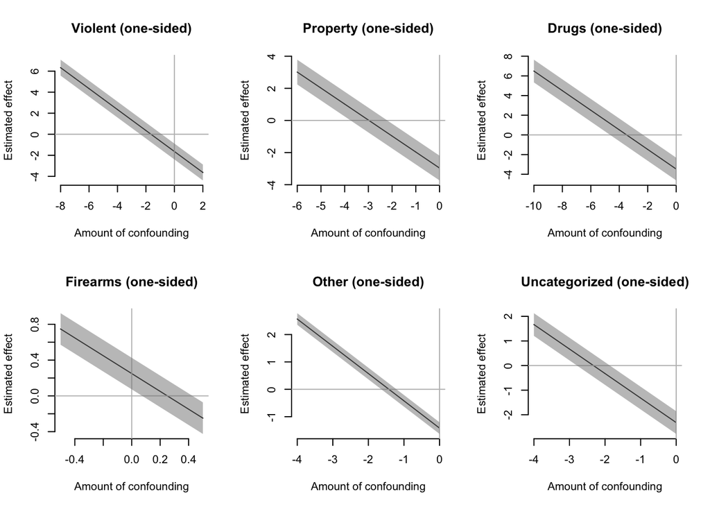

```r
model.t<-glm(treatment~arrests_violent+arrests_property+
               arrests_drugs+arrests_firearms+arrests_other+
               arrests_uncategorized, data=matched_data2,
             family=binomial())

alpha_violent_1=seq(-8, 2, by=0.01)
sens_violent_1 <- causalsens(lm_violent, model.t,
                      ~ arrests_violent+arrests_property+arrests_drugs+
                        arrests_firearms+arrests_other+arrests_uncategorized,
                      data = matched_data2,  confound = one.sided, alpha=alpha_violent_1)
alpha_property_1=seq(-6, 0, by=0.01)
sens_property_1 <- causalsens(lm_property, model.t,
                      ~ arrests_violent+arrests_property+arrests_drugs+
                        arrests_firearms+arrests_other+arrests_uncategorized,
                      data = matched_data2,  confound = one.sided, alpha=alpha_property_1)
alpha_drugs_1=seq(-10, 0, by=0.01)
sens_drugs_1<-causalsens(lm_drugs, model.t,
                      ~ arrests_violent+arrests_property+arrests_drugs+
                        arrests_firearms+arrests_other+arrests_uncategorized,
                      data = matched_data2,  confound = one.sided, alpha=alpha_drugs_1)
alpha_firearms_1=seq(-0.5, 0.5, by=0.01)
sens_firearms_1<-causalsens(lm_firearms, model.t,
                      ~ arrests_violent+arrests_property+arrests_drugs+
                        arrests_firearms+arrests_other+arrests_uncategorized,
                      data = matched_data2,  confound = one.sided, alpha=alpha_firearms_1)
alpha_other_1=seq(-4, 0, by=0.01)
sens_other_1<-causalsens(lm_other, model.t,
                      ~ arrests_violent+arrests_property+arrests_drugs+
                        arrests_firearms+arrests_other+arrests_uncategorized,
                      data = matched_data2,  confound = one.sided, alpha=alpha_other_1)
alpha_uncategorized_1=seq(-4, 0, by=0.01)
sens_uncategorized_1<-causalsens(lm_uncategorized, model.t,
                      ~ arrests_violent+arrests_property+arrests_drugs+
                        arrests_firearms+arrests_other+arrests_uncategorized,
                      data = matched_data2,  confound = one.sided, alpha=alpha_uncategorized_1)

#a function to extract the value of alpha (amoung of selection bias=amount of confounding)
#and the R-squared at which our causal estimates would lose statistical significance.
cnf_val<-function(X)
{
  ind<-min(which(X$lower<0))
  c(X[ind, "alpha"], X[ind, "rsqs"])
}
confounding_values<-as.data.frame(
  rbind(
    cnf_val(sens_violent_1$sens),
    cnf_val(sens_property_1$sens),
    cnf_val(sens_drugs_1$sens),
    cnf_val(sens_firearms_1$sens),
    cnf_val(sens_other_1$sens),
    cnf_val(sens_uncategorized_1$sens)
  )
)

types<-c("violent", "property", "drugs", "firearms", "other", "uncategorized")
row.names(confounding_values)<-types
colnames(confounding_values)<-c("alpha", "rsqs")

control_means<-filter(means, type=="charge")[, c("group", "control")][c(6, 4, 1, 2, 3, 5),]
confounding_values[,"percent"]<-confounding_values$alpha/control_means$control



par(mfrow=c(2, 3))
plot(sens_violent_1, type = "raw", bty = "n", main="Violent (one-sided)")
plot(sens_property_1, type = "raw", bty = "n", main="Property (one-sided)")
plot(sens_drugs_1, type = "raw", bty = "n", main="Drugs (one-sided)")
plot(sens_firearms_1, type = "raw", bty = "n", main="Firearms (one-sided)")
plot(sens_other_1, type = "raw", bty = "n", main="Other (one-sided)")
plot(sens_uncategorized_1, type = "raw", bty = "n", main="Uncategorized (one-sided)")
```

The results of our sensitivity analysis are as follows:

- *Violent offenses:* An unobserved covariate would have to on average result in 2.4 (a 8.7 decrease from control) fewer charges per day between cases tried pre and post Krasner to reverse our conclusion that Krasner’s DAO caused a statistically significant decrease in violent charges controlling for arrests.
- *Property offenses:* An unobserved covariate would have to on average result in 3.74 (a 19.6 decrease from control) fewer charges per day between cases tried pre and post Krasner to reverse our conclusion that Krasner’s DAO caused a statistically significant decrease in property charges controlling for arrests.
- *Drug offenses:* An unobserved covariate would have to on average result in 4.64 (a 11.2 decrease from control) fewer charges per day between cases tried pre and post Krasner to reverse our conclusion that Krasner’s DAO caused a statistically significant decrease in drug charges controlling for arrests.
- *Firearms offenses:* An unobserved covariate would have to on average result in 0.08 (a 2.6 increase from control) more charges per day between cases tried pre and post Krasner to reverse our conclusion that Krasner’s DAO caused a statistically significant increase in firearms charges controlling for arrests.
- *Other offenses:* An unobserved covariate would have to on average result in 1.63 (a 40.1 decrease from control) fewer charges per day between cases tried pre and post Krasner to reverse our conclusion that Krasner’s DAO caused a statistically significant decrease in other charges controlling for arrests.
- *Uncategorized offenses:* An unobserved covariate would have to on average result in 2.78 (a 22.2 decrease from control) fewer charges per day between cases tried pre and post Krasner to reverse our conclusion that Krasner’s DAO caused a statistically significant decrease in uncategorized charges controlling for arrests.

We see that our conclusions for property, other, and uncategorized offenses are quite robust to effects of potential unobserved covariates and our conclusions for drug and violent offenses are moderately so. However, our conclusion that Krasner’s office caused an increase in charges for firearms offenses controlling for arrests is quite sensitive to the effects of potential unobserved covariates.

Austen, Ben. 2018. “In Philadelphia, a Progressive D.a. Tests the Power — and Learns the Limits — of His Office.” *New York Times*. https://www.nytimes.com/2018/10/30/magazine/larry-krasner-philadelphia-district-attorney-progressive.html.

Blackwell, Matthew. 2014. “A Selection Bias Approach to Sensitivity Analysis for Causal Effects.” *Political Analysis* 22 (2): 169–82.

Daniel E. Ho, Gary King, Kosuke Imai, and Elizabeth A. Stuart. 2007. “Matching as Nonparametric Preprocessing for Reducing Model Dependence in Parametric Causal Inference.” *Political Analysis* 15 (199).

King, Gary, Gary King, and Langche Zeng. 2006. “The Dangers of Extreme Counterfactuals.” *Political Analysis* 14 (2): 131–59.

“Krasner for Da.” n.d. https://web.archive.org/web/20171013182105/https://krasnerforda.com/.

“Krasner for Da: Promises Kept.” n.d. https://krasnerforda.com/promises-kept.

“Philadelphia Dao Data Dashboard.” n.d. https://data.philadao.com/.

“Philadelphia Dao Github Repository.” n.d. https://github.com/phillydao/phillydao-public-data/tree/master/docs/data.